# Institutional sellers vs keepers

Canopy disturbance on CFP land, Houghton & Keweenaw Counties

Authors

Randy Swaty

Julia Petersen

Published

October 26, 2026

### Question (from the drawing)

Among land held by **institutional owners** in 2020, did owners who **sold** by 2026 disturb their land more than owners who **kept** it? Major disturbance = mean parcel canopy cover (TCC) dropping more than 20 percentage points, 2020 → 2025.

### Short answer

So “sold vs kept” matters less than **who the land was sold to and when**. All loss observed on both footprints happened while TRG/Verdant still owned the land (TCC ends in 2025; Hansen in 2024).

### Roster

| Firm label | 2020 CFP name match | Notes |
| --- | --- | --- |
| **TRG** | `TRG THRESHOLD…`, later `Verdant…` | Verdant treated as same-family rebrand, not a sale |
| **Lyme** | `LYME…` | Small (28 parcels) |
| **MWF** | `MWF…` | Molpus-family stand-in; no literal “Molpus” in HK CFP |
| **Manulife** | `MANULIFE…`, Hancock | **No parcels** in HK CFP 2020 |

### How “sold” is defined

- **Songbird / Heartlands:** parcels with ≥50% of their area inside the footprint polygons (Emma’s Songbird layer, ~17,236 GIS acres; Keweenaw Heartlands, ~32,579 GIS acres). The 2026 CFP file still lists Songbird land as **Verdant** because the sale happened after that snapshot, so names alone would misclassify it as kept.
- **Other sale:** legal name changed to a different owner family, or parcel left CFP.
- **Kept:** same name, or TRG → Verdant rebrand.

### Parcel-level results by exit type

| Firm | Outcome | Parcels | Acres | Major-loss parcels | % parcels | % acres | Mean ΔTCC (pp) |
| --- | --- | --- | --- | --- | --- | --- | --- |
| Lyme | Kept (same name) | 28 | 1,686 | 1 | 3.6 | 2.4 | -1.3 |
| MWF | Kept (same name) | 22 | 4,820 | 3 | 13.6 | 24.1 | -9.0 |
| MWF | Other sale | 4 | 560 | 1 | 25.0 | 21.4 | -9.6 |
| TRG | Kept (TRG → Verdant) | 497 | 105,901 | 37 | 7.4 | 6.5 | -1.3 |
| TRG | Sold to TNC (Heartlands) | 152 | 30,973 | 0 | 0.0 | 0.0 | 4.4 |
| TRG | Sold to Songbird (2026) | 91 | 15,350 | 18 | 19.8 | 20.2 | -7.7 |
| TRG | Other sale | 83 | 10,819 | 1 | 1.2 | 0.4 | 3.2 |
| TRG | Left CFP | 15 | 1,781 | 0 | 0.0 | 0.0 | 5.1 |

### Pixel-level check (whole footprints, 30 m)

Parcel means can blur cuts on big parcels, so the same zones were summarised pixel by pixel. “Before” is 2015–2020, “after” is 2020–2025.

| Zone | Acres | ΔTCC before | ΔTCC after | % area >20 pp drop, after | Hansen loss % 2015–19 | Hansen loss % 2020–24 |
| --- | --- | --- | --- | --- | --- | --- |
| TRG/Verdant retained | 105,002 | -0.7 | -1.5 | 8.3 | 2.7 | 6.3 |
| TRG other sale / left CFP | 13,111 | 1.6 | 3.2 | 1.9 | 3.6 | 2.0 |
| Lyme | 1,696 | -0.2 | -0.8 | 3.1 | 0.1 | 0.4 |
| MWF | 5,416 | 1.7 | -12.9 | 21.6 | 0.0 | 3.3 |
| Non-institutional kept | 116,911 | 0.4 | 1.0 | 2.4 | 0.9 | 0.6 |
| Non-institutional sold / left | 41,845 | 0.7 | 0.5 | 5.1 | 2.8 | 1.6 |
| Heartlands (TRG to TNC) | 30,543 | -0.0 | 5.0 | 1.8 | 3.2 | 4.9 |
| Songbird (TRG to Songbird, 2026) | 15,153 | 3.0 | -8.0 | 17.7 | 4.5 | 6.6 |

Songbird land was **gaining** canopy before 2020 (+3.0 pp) and then lost 8.0 pp after, so the drop is not a continuation of an older trend.

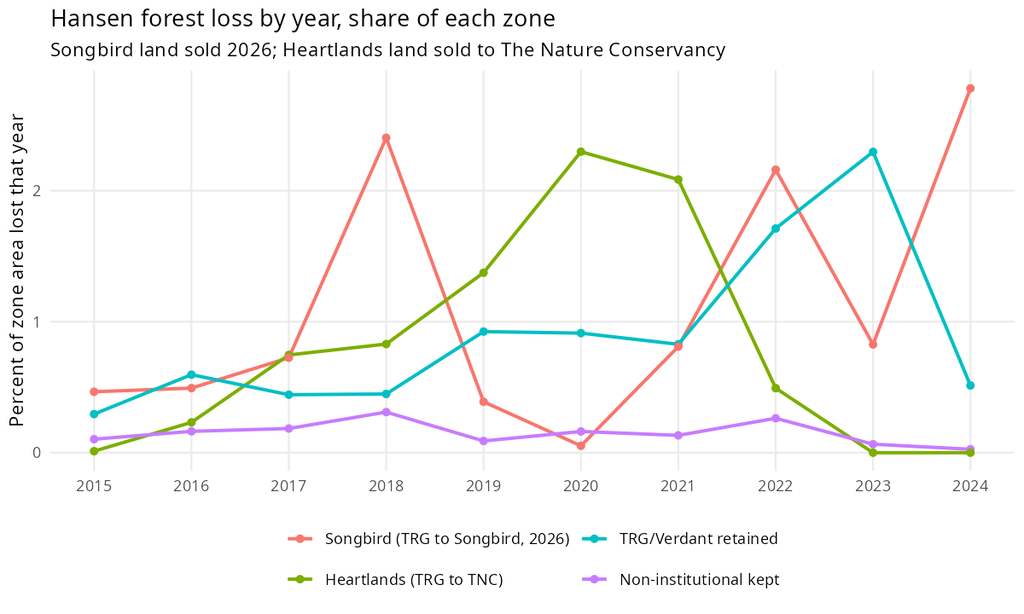

Hansen forest loss by year for the sale footprints, retained TRG/Verdant land, and non-institutional land kept by its owner.

### Secondary comparison: institutional vs non-institutional

The drawing sets non-institutional owners aside as apples-to-oranges, but suggests comparing sellers as collectives:

| Owner class | Cohort | Parcels | Acres | Major-loss parcels | % parcels | % acres |
| --- | --- | --- | --- | --- | --- | --- |
| Institutional | keeper | 547 | 112,407 | 41 | 7.5 | 7.2 |
| Institutional | seller | 345 | 59,483 | 20 | 5.8 | 5.5 |
| Non-institutional | keeper | 910 | 116,315 | 3 | 0.3 | 0.3 |
| Non-institutional | seller | 326 | 41,888 | 8 | 2.5 | 1.5 |

Institutional land has about 23× the major-loss rate of non-institutional land among keepers and about 2× among sellers. Among non-institutional owners, sellers had major loss on 2.5% of parcels and keepers on 0.3%; both are well below either institutional group.

### By firm

- **TRG** drives almost everything (838 of 892 institutional parcels).
- **MWF** is small (~5,400 ac) but has the steepest canopy decline of any zone (-12.9 pp, harvest 2022–2024), mostly on land it **kept**.
- **Lyme** shows little disturbance.
- **Manulife** has no CFP land here.

### Methods

- **Scripts:** `scripts/09_cfp_parcel_tcc_change.R` (parcel TCC), `scripts/10_institutional_sellers_vs_keepers.R` (parcel classes and rates), `scripts/11_sale_footprint_pixels.R` (pixel zones and Hansen timing).
- **Footprints:** `inputs/boundaries/american_songbird.shp`, `inputs/boundaries/keweenaw_heartlands.shp`.
- **Outputs:** `output_csvs/cfp_institutional_*.csv`, `cfp_sellers_by_owner_class.csv`, `cfp_sale_footprint_*.csv`, `output_visuals/cfp_sale_footprint_hansen_by_year.png`.